# EDA LAB1

Bruna Barbosa

```r
episodesHouseOfCards = read_csv(here("data/series_from_imdb.csv"),
                    progress = FALSE,
                    col_types = cols(.default = col_double(),
                                     series_name = col_character(),
                                     episode = col_character(),
                                     url = col_character(),
                                     season = col_character())) %>%
    filter(series_name == "House of Cards")
```

Analisaremos os episodios da serie House of Cards e da serie Game of Thrones.

## House of Cards

### Quantas avaliacoes temos por episodio?

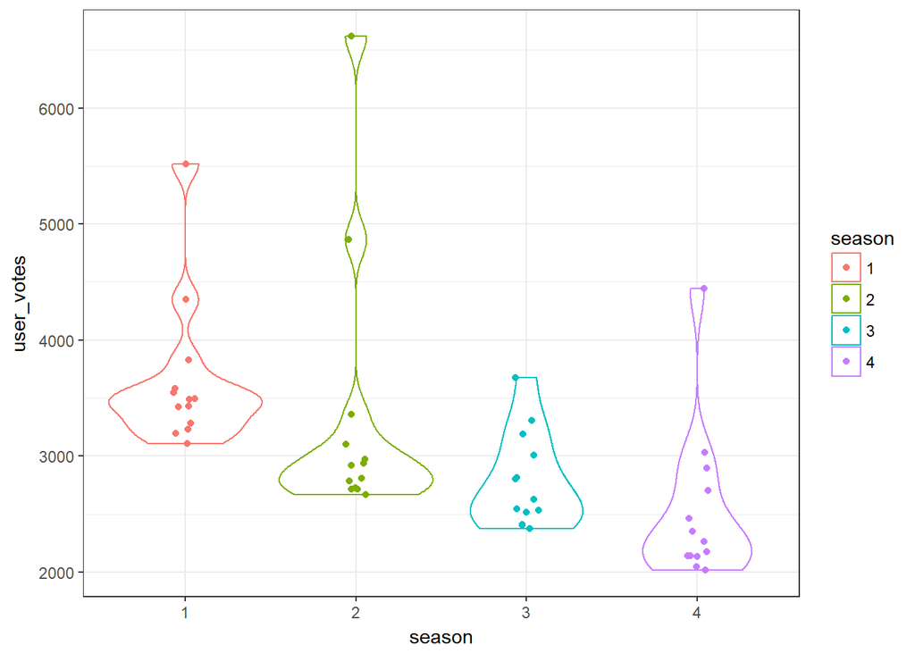

```r
episodesHouseOfCards %>%
    ggplot(aes(x = season, y = user_votes, color = season)) +
    geom_violin() +
    geom_jitter(width = .07)
```

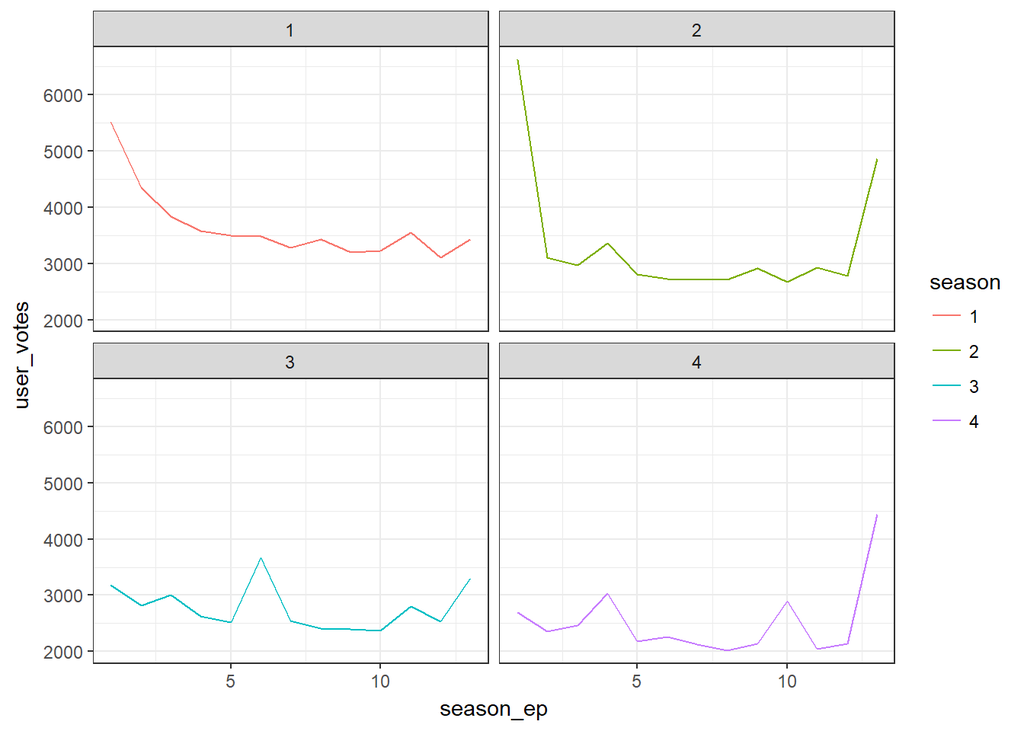

```r
episodesHouseOfCards %>%
    ggplot(aes(x = season_ep, y = user_votes, color = season))  +
    geom_line() +
    facet_wrap(~ season)
```

O numero de de avaliacoes sofreu uma leve queda, apenas o que destoa da tendencia sao os episodios season premiere e season finale.

O declinio de avaliacoes pode ter sido causado por um numero menor de assinantes do Netflix assistindo a serie. O servico nao revela dados de audiencia, divulga apenas o numero total de assinantes.

### As avaliacoes sao boas?

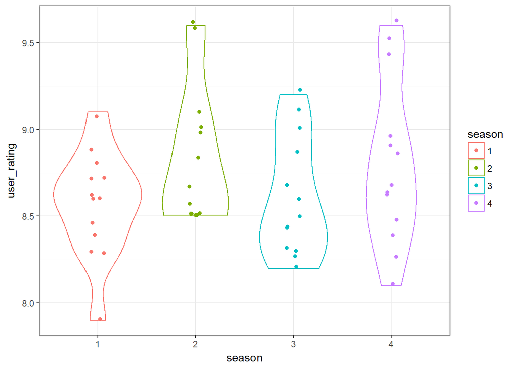

```r
episodesHouseOfCards %>%
    ggplot(aes(x = season, y = user_rating, color = season)) +
    geom_violin() +
    geom_jitter(width = .07)
```

A serie possui uma qualidade boa e regular, com a maioria dos usuarios avaliando os episodios acima de 8.

### A qualidade da serie vem crescendo?

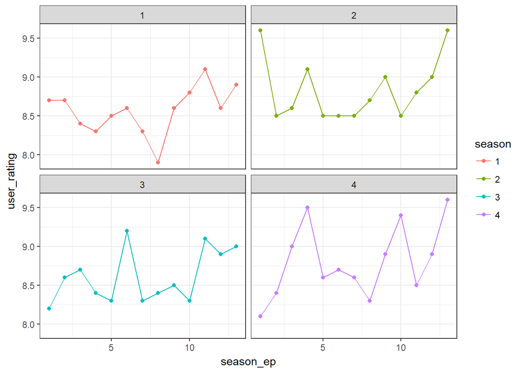

```r
episodesHouseOfCards %>%
  ggplot(aes(x = season_ep, y = user_rating, color = season)) +
  geom_line() +
  geom_point() +
  facet_wrap(~ season)
```

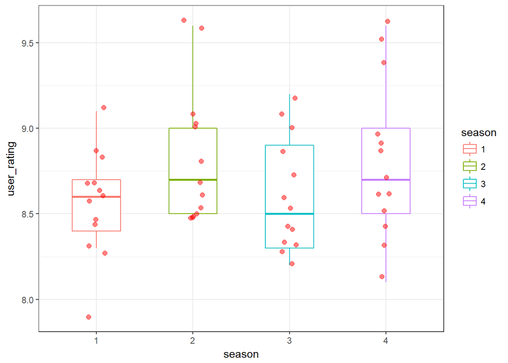

```r
episodesHouseOfCards %>%
    ggplot(aes(x = season, y = user_rating, color = season)) +
    geom_boxplot(width = .5, outlier.color = NA) +
    geom_jitter(width = .1, size = 2, alpha = .5, color = "red")
```

A qualidade vem mantendo seu patamar de avaliacao, com a maioria dos usuarios atribuindo notas acima de 8.

### Um maior numero de avaliacoes indica maior qualidade por episodio?

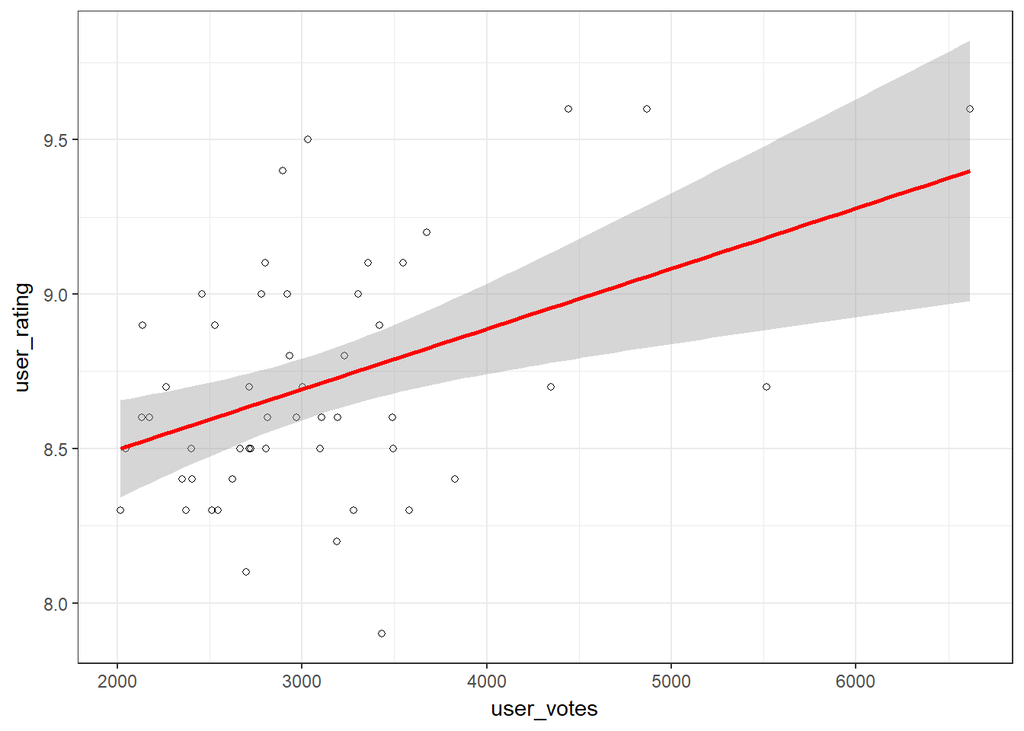

```r
ggplot(episodesHouseOfCards, aes(x=user_votes, y=user_rating)) +
  geom_point(shape=1) + geom_smooth(method=lm , color="red", se=TRUE) # Add linear regression line
```

```r
episodesHouseOfCards %>%
    group_by(season) %>%
    summarise(correlacao_linear = cor(user_votes, user_rating,
                                      method = "pearson"),
              correlacao_kendall = cor(user_votes, user_rating,
                                       method = "kendall"))
```

| season | correlacao_linear | correlacao_kendall |
| --- | --- | --- |
| 1 | 0.1354333 | 0.0397569 |
| 2 | 0.8336790 | 0.5190204 |
| 3 | 0.5817191 | 0.3685487 |
| 4 | 0.6827822 | 0.4935481 |

Alguns episodios de maior qualidade receberam um maior numero de avaliacoes, porem nem sempre isso ocorre.

### Os fas da serie vem crescendo?

Sao considerados fas usuarios que atribuiram a nota 10 ao seriado.

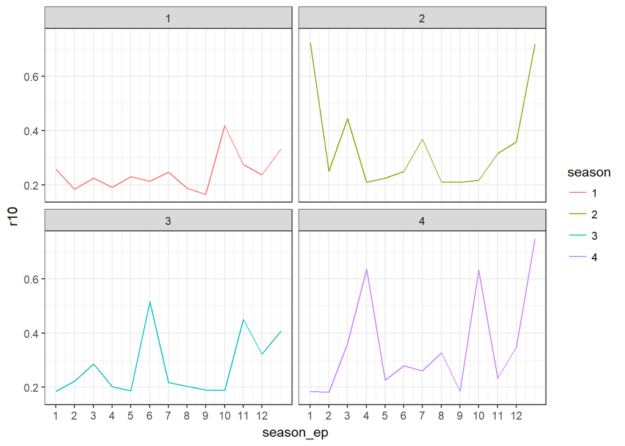

```r
episodesHouseOfCards %>%
    ggplot(aes(x = season_ep, y = r10, color = season)) +
    geom_line() +
    scale_x_continuous(breaks = 1:12) +
    facet_wrap(~ season)
```

Nao é possivel identificar uma tendencia no aumento ou declinio do numero de fas deste seriado.

## Game of Thrones

```r
episodesGameOfThrones = read_csv(here("data/series_from_imdb.csv"),
                    progress = FALSE,
                    col_types = cols(.default = col_double(),
                                     series_name = col_character(),
                                     episode = col_character(),
                                     url = col_character(),
                                     season = col_character())) %>%
    filter(series_name == "Game of Thrones")
```

### Quantas avaliacoes temos por episodio?

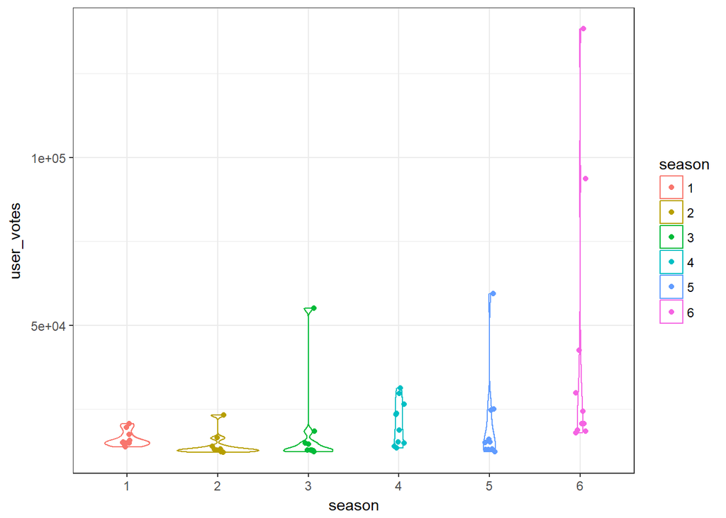

```r
episodesGameOfThrones %>%
    ggplot(aes(x = season, y = user_votes, color = season)) +
    geom_violin() +
    geom_jitter(width = .07)
```

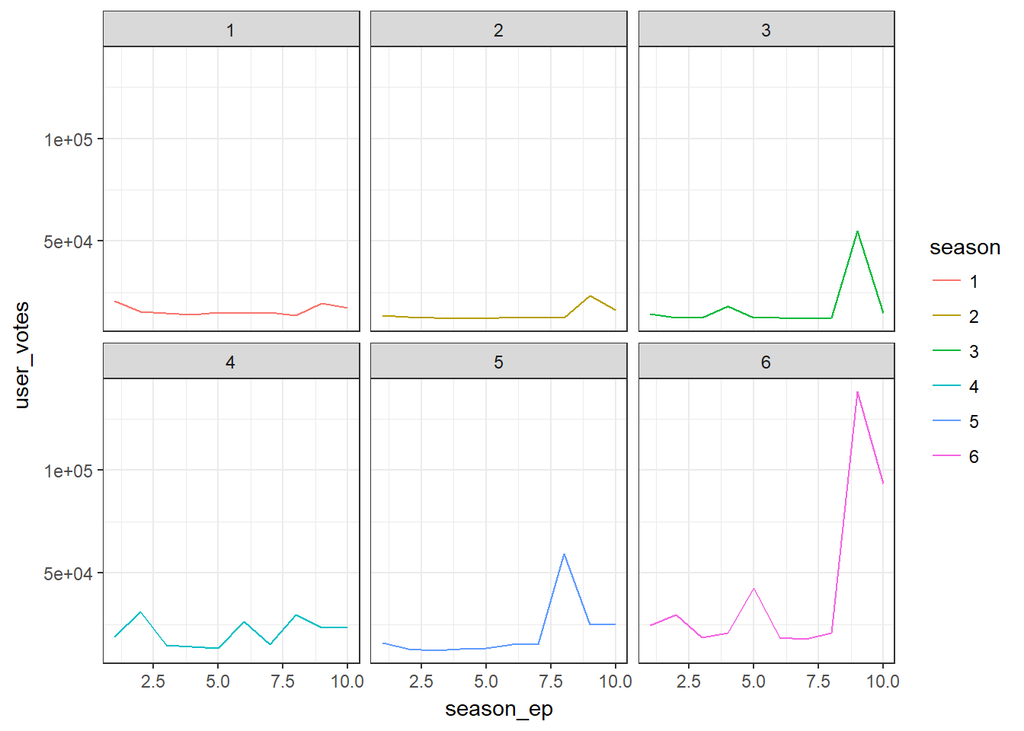

```r
episodesGameOfThrones %>%
    ggplot(aes(x = season_ep, y = user_votes, color = season))  +
    geom_line() +
    facet_wrap(~ season)
```

### As avaliacoes sao boas?

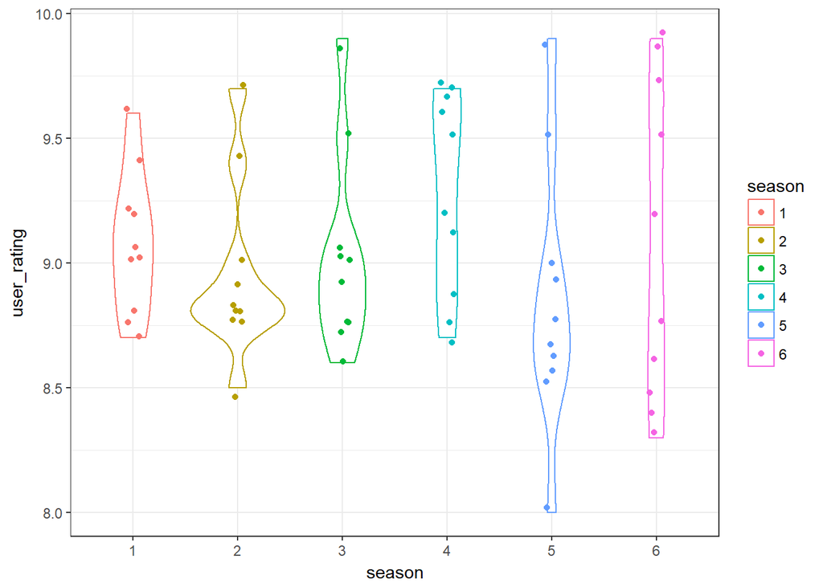

```r
episodesGameOfThrones %>%
    ggplot(aes(x = season, y = user_rating, color = season)) +
    geom_violin() +
    geom_jitter(width = .07)
```

A serie possui uma qualidade boa e regular, com a maioria dos usuarios avaliando os episodios acima de 8,5.

Umas das series mais bem avaliadas do site IMDB.

### A qualidade da serie vem crescendo?

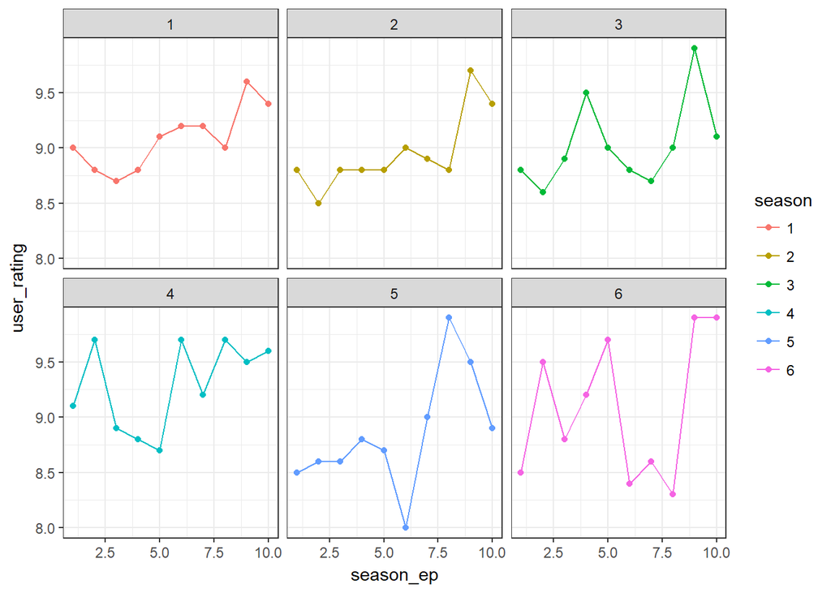

```r
episodesGameOfThrones %>%
  ggplot(aes(x = season_ep, y = user_rating, color = season)) +
  geom_line() +
  geom_point() +
  facet_wrap(~ season)
```

A qualidade é alta e constante.

Diferentemente das outras series, o penultimo episodio de cada temporada é o mais bem avaliados na maioria dos casos.

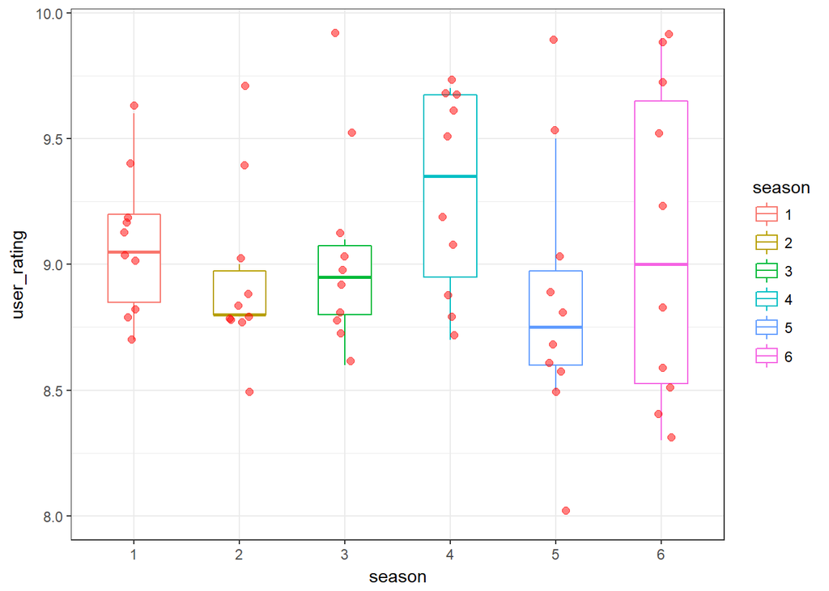

```r
episodesGameOfThrones %>%
    ggplot(aes(x = season, y = user_rating, color = season)) +
    geom_boxplot(width = .5, outlier.color = NA) +
    geom_jitter(width = .1, size = 2, alpha = .5, color = "red")
```

A qualidade vem mantendo seu patamar de avaliacao, com a maioria dos usuarios atribuindo notas acima de 8,5.

### Um maior numero de avaliacoes indica maior qualidade por episodio?

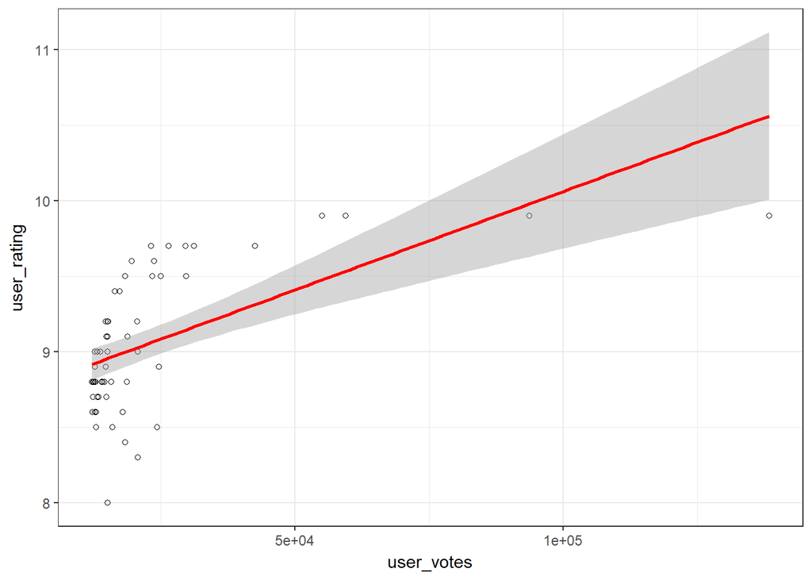

```r
ggplot(episodesGameOfThrones, aes(x=user_votes, y=user_rating)) +
  geom_point(shape=1) + geom_smooth(method=lm , color="red", se=TRUE) # Add linear regression line
```

```r
episodesGameOfThrones %>%
    group_by(season) %>%
    summarise(correlacao_linear = cor(user_votes, user_rating,
                                      method = "pearson"),
              correlacao_kendall = cor(user_votes, user_rating,
                                       method = "kendall"))
```

| season | correlacao_linear | correlacao_kendall |
| --- | --- | --- |
| 1 | 0.4827907 | 0.3220306 |
| 2 | 0.8898372 | 0.4787550 |
| 3 | 0.8398303 | 0.5683286 |
| 4 | 0.9380782 | 0.9200874 |
| 5 | 0.7942729 | 0.4045199 |
| 6 | 0.7495093 | 0.6292532 |

Geralmente a qualidade e o numero de avaliacoes nao variam muito. Porem ha algumas excecoes, como o episidio battle of the bastards, que obteve um maior numero de avaliacoes.

### Os fas da serie vem crescendo?

Sao considerados fas usuarios que atribuiram a nota 10 ao seriado.

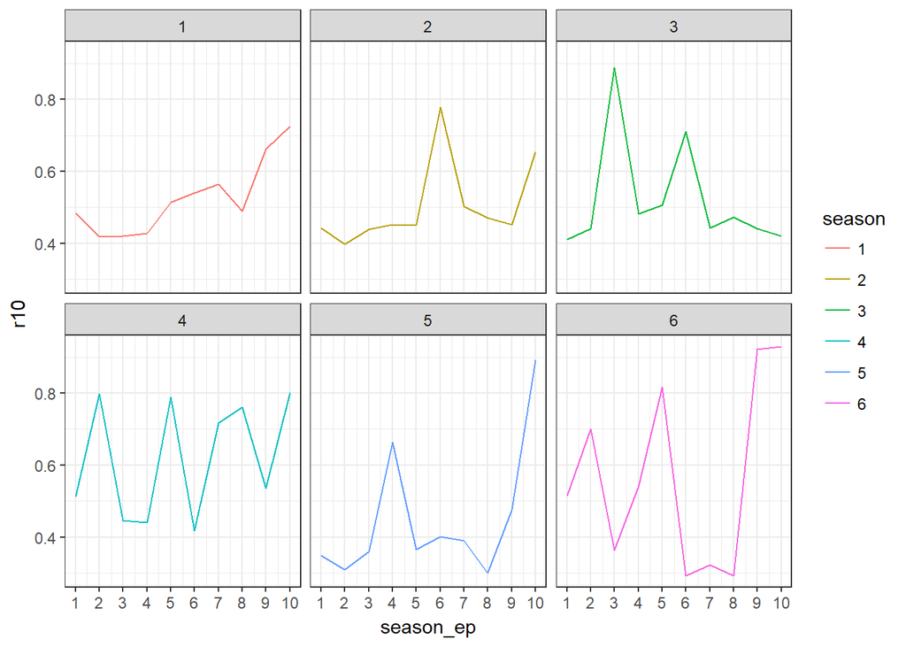

```r
episodesGameOfThrones %>%
    ggplot(aes(x = season_ep, y = r10, color = season)) +
    geom_line() +
    scale_x_continuous(breaks = 1:12) +
    facet_wrap(~ season)
```

Nao é possivel identificar uma tendencia no aumento ou declinio do numero de fas deste seriado. A qualidade da serie vem se mostrando consistente.

## Conclusao

As duas series foram bem avaliadas, mantendo sua qualidade com o passar do tempo. Sendo game of thrones um pouco melhor avaliada e mantendo sua base de fas constante.